# nimbusmart_notebook

> NimbusMart is a 2-year-old online retailer selling across Electronics, Home & Kitchen, Fashion, Beauty, Sports & Outdoors, and Books & Media. We grew steadily through 2024 and into early 2025 — but starting around Q3 2025, revenue has clearly softened, and even our Nov-Dec 2025 holiday season came in below last year's, which has never happened before.

> We've tried throwing more discounts at the problem, but it doesn't seem to be working — margins are getting worse without a real sales recovery. My leadership team has a few theories (competitor activity in some regions, slower delivery, ad spend not converting like it used to, product quality issues) but no one has actually looked at the data.

> Attached is our raw order-level transaction data for the last 2 years (~100,000 orders). Can you dig in and tell us:
> 1. What's actually driving the decline — is it fewer customers, fewer orders per customer, lower basket size, or something else?
> 2. Which regions, categories, channels, or marketing sources are underperforming, and is that difference statistically real or just noise?
> 3. Are we losing our best customers, or is this a broad-based problem?
> 4. What would you recommend we do about it — and how big could that fix be?

> We need this to go beyond "here's a dashboard" — we want to know the *why* and the *so what*.

## Data Dictionary

| Column | Description |
| --- | --- |
| `order_id` | Unique order identifier |
| `order_date` | Date of purchase (YYYY-MM-DD) |
| `customer_id` | Unique customer identifier |
| `customer_signup_date` | When the customer first registered |
| `customer_region` | North / South / East / West / Central |
| `customer_gender` | Male / Female / Other |
| `customer_age` | Customer age |
| `marketing_source` | Acquisition channel: Organic Search, Paid Ads, Referral, Email, Social Media |
| `loyalty_tier` | Internal behavioral tier: Low / Medium / High (proxy for purchase frequency propensity) |
| `product_id` | SKU identifier |
| `category` | Electronics, Home & Kitchen, Fashion, Beauty, Sports & Outdoors, Books & Media |
| `subcategory` | Sub-category within the category |
| `unit_price` | Price per unit ($) |
| `quantity` | Units purchased in this order line |
| `discount_pct` | Discount applied (%) |
| `total_amount` | Final amount paid ($), after discount |
| `channel` | Website / Mobile App / Marketplace |
| `payment_method` | Payment method used |
| `delivery_days` | Days taken to deliver |
| `return_flag` | 1 if the order was returned, else 0 |
| `customer_rating` | Post-purchase rating (1–5) |

*(Note: I did not tell you where the problem lives. Some patterns are subtle and some regions/categories/segments are red herrings — that's intentional, and it's exactly what makes this a realistic exercise rather than a lookup exercise.)*

## Problem Statement : The Revenue of NimbusMart is declining since the Q3 2025 and the Q4 2025 revenue was also less than Q4 2024 revenue.

### Problem-Solving :

In an Ecommerce Business, Revenue is drived by the No of Active Customers, Avg number of orders per customer, Avg amount of order per each customer.

**Revenue = No of Active Customer x avg number of orders per customer x avg amount of order per each customer.**

Lets investigate each factor:

1. No of Active Customer:

What is an active Customer ? As the data is about quarters, we assume an active customer is a customer who makes at least one purchase in each quarter, that is about 4 orders per annum.

**No of Active Customers = Avg No of new customers acquired + (No of active customers in previous quarter * Avg Customer Retention Rate)**

Now for any stable business, the rate of retention is about 30%. And Lets assume that the number of new customers being acquired are 1000 per month that is about 3000 per quarter.

So the customer base roughly becomes like:

```
no of active customers in Q1 2024 = 3000 + ( 0 * 0.3 ) = 3000
no of active customers in Q2 2024 = 3000 + ( 3000 * 0.3 ) = 3900
no of active customers in Q3 2024 = 3000 + ( 3900 * 0.3 ) = 4170
no of active customers in Q4 2024 = 3000 + ( 4170 * 0.3 ) = 4250
no of active customers in Q1 2025 = 3000 + ( 4250 * 0.3 ) = 4275
no of active customers in Q2 2025 = 3000 + ( 4275 * 0.3 ) = 4282
no of active customers in Q3 2025 = 3000 + ( 4282 * 0.3 ) = 4284
no of active customers in Q4 2025 = 3000 + ( 4284 * 0.3 ) = 4285
```

- We see that after Q2 in 2025, the customer base became almost static. Apparently this was the time when the business revenue went downward.
2. Avg Number of orders was considered to be 4 annually.
3. Now Avg Amount of order per each customer.
- This number has to be assumed.
- Lets say an avg order will have 1 basic electronic (~1200 - ~2500), 2 Home and kitchen(~800 - ~1400), 4 Fashion Elements(~2000 - ~4000), 1 Sports and outdoor(~1000 - ~1400), and 1 book(~200).
- So, an estimated total can be ~5200 - ~9500 Rupees.

So if the Revenue Dopped in the third Quarter of 2025, Either or a combination of the drivers faced a decrease in number. Lets find that out using data.

```python
import pandas as pd
import numpy as np
import seaborn as sns
import matplotlib.pyplot as plt
```

```python
df = pd.read_csv("nimbusmart_sales_data.csv")
```

```python
df.head()
```

|  | order_id | order_date | customer_id | customer_signup_date | customer_region | customer_gender | customer_age | marketing_source | loyalty_tier | product_id | ... | subcategory | unit_price | quantity | discount_pct | total_amount | channel | payment_method | delivery_days | return_flag | customer_rating |
| --- | --- | --- | --- | --- | --- | --- | --- | --- | --- | --- | --- | --- | --- | --- | --- | --- | --- | --- | --- | --- | --- |
| 0 | ORD585279 | 2024-01-01 | CUST112178 | 2024-01-26 | South | Male | 18 | Referral | High | P0142 | ... | Cycling Accessories | 141.50 | 2 | 2.4 | 276.21 | Website | Credit Card | 3 | 0 | 4 |
| 1 | ORD594380 | 2024-01-01 | CUST112083 | 2024-01-05 | South | Female | 56 | Social Media | Medium | P0131 | ... | Yoga | 48.39 | 1 | 11.9 | 42.63 | Website | UPI/Net Banking | 2 | 0 | 5 |
| 2 | ORD552020 | 2024-01-01 | CUST114370 | 2024-01-28 | North | Male | 33 | Paid Ads | Medium | P0052 | ... | Decor | 134.50 | 1 | 4.3 | 128.72 | Website | Credit Card | 5 | 0 | 3 |
| 3 | ORD522721 | 2024-01-01 | CUST103632 | 2024-01-28 | South | Female | 60 | Referral | Medium | P0105 | ... | Makeup | 60.75 | 1 | 7.2 | 56.38 | Mobile App | Credit Card | 4 | 0 | 4 |
| 4 | ORD578390 | 2024-01-01 | CUST106615 | 2024-01-19 | North | Male | 39 | Organic Search | Low | P0145 | ... | Sportswear | 116.60 | 2 | 2.5 | 227.37 | Website | Credit Card | 2 | 0 | 5 |

5 rows × 21 columns

```python
df.info()
```

```
<class 'pandas.core.frame.DataFrame'>
RangeIndex: 100000 entries, 0 to 99999
Data columns (total 21 columns):
 #   Column                Non-Null Count   Dtype
---  ------                --------------   -----
 0   order_id              100000 non-null  object
 1   order_date            100000 non-null  object
 2   customer_id           100000 non-null  object
 3   customer_signup_date  100000 non-null  object
 4   customer_region       100000 non-null  object
 5   customer_gender       100000 non-null  object
 6   customer_age          100000 non-null  int64
 7   marketing_source      100000 non-null  object
 8   loyalty_tier          100000 non-null  object
 9   product_id            100000 non-null  object
 10  category              100000 non-null  object
 11  subcategory           100000 non-null  object
 12  unit_price            100000 non-null  float64
 13  quantity              100000 non-null  int64
 14  discount_pct          100000 non-null  float64
 15  total_amount          100000 non-null  float64
 16  channel               100000 non-null  object
 17  payment_method        100000 non-null  object
 18  delivery_days         100000 non-null  int64
 19  return_flag           100000 non-null  int64
 20  customer_rating       100000 non-null  int64
dtypes: float64(3), int64(5), object(13)
memory usage: 16.0+ MB
```

```python
df['order_date'] = pd.to_datetime(df['order_date'])
df['customer_signup_date'] = pd.to_datetime(df['customer_signup_date'])
```

```python
df.info()
```

```
<class 'pandas.core.frame.DataFrame'>
RangeIndex: 100000 entries, 0 to 99999
Data columns (total 21 columns):
 #   Column                Non-Null Count   Dtype
---  ------                --------------   -----
 0   order_id              100000 non-null  object
 1   order_date            100000 non-null  datetime64[ns]
 2   customer_id           100000 non-null  object
 3   customer_signup_date  100000 non-null  datetime64[ns]
 4   customer_region       100000 non-null  object
 5   customer_gender       100000 non-null  object
 6   customer_age          100000 non-null  int64
 7   marketing_source      100000 non-null  object
 8   loyalty_tier          100000 non-null  object
 9   product_id            100000 non-null  object
 10  category              100000 non-null  object
 11  subcategory           100000 non-null  object
 12  unit_price            100000 non-null  float64
 13  quantity              100000 non-null  int64
 14  discount_pct          100000 non-null  float64
 15  total_amount          100000 non-null  float64
 16  channel               100000 non-null  object
 17  payment_method        100000 non-null  object
 18  delivery_days         100000 non-null  int64
 19  return_flag           100000 non-null  int64
 20  customer_rating       100000 non-null  int64
dtypes: datetime64[ns](2), float64(3), int64(5), object(11)
memory usage: 16.0+ MB
```

```python
df.describe().T
```

|  | count | mean | min | 25% | 50% | 75% | max | std |
| --- | --- | --- | --- | --- | --- | --- | --- | --- |
| order_date | 100000 | 2025-01-20 13:36:46.943999744 | 2024-01-01 00:00:00 | 2024-08-09 00:00:00 | 2025-01-12 00:00:00 | 2025-07-16 00:00:00 | 2025-12-31 00:00:00 | NaN |
| customer_signup_date | 100000 | 2024-07-18 11:27:14.400000 | 2024-01-01 00:00:00 | 2024-03-06 00:00:00 | 2024-06-08 00:00:00 | 2024-10-29 00:00:00 | 2025-12-31 00:00:00 | NaN |
| customer_age | 100000.0 | 40.81736 | 18.0 | 29.0 | 41.0 | 53.0 | 64.0 | 13.630677 |
| unit_price | 100000.0 | 67.145353 | 5.92 | 31.02 | 59.82 | 102.09 | 188.7 | 43.777336 |
| quantity | 100000.0 | 1.99728 | 1.0 | 1.0 | 2.0 | 3.0 | 4.0 | 1.068384 |
| discount_pct | 100000.0 | 10.424552 | 0.0 | 4.1 | 8.2 | 13.4 | 36.9 | 8.450892 |
| total_amount | 100000.0 | 118.766614 | 3.13 | 39.5575 | 84.385 | 156.1925 | 744.04 | 110.175726 |
| delivery_days | 100000.0 | 4.20756 | 1.0 | 3.0 | 4.0 | 5.0 | 13.0 | 1.486204 |
| return_flag | 100000.0 | 0.0747 | 0.0 | 0.0 | 0.0 | 0.0 | 1.0 | 0.262908 |
| customer_rating | 100000.0 | 3.86959 | 1.0 | 3.0 | 4.0 | 5.0 | 5.0 | 0.926203 |

### High Level Analytical Questions:

1. What is the trend in no of active customers in each quarter ?
2. Avg Number of order placed in each quarter ?
3. Avg Amount of order placed in each quarter ?

```python
df.columns
```

```
Index(['order_id', 'order_date', 'customer_id', 'customer_signup_date',
       'customer_region', 'customer_gender', 'customer_age',
       'marketing_source', 'loyalty_tier', 'product_id', 'category',
       'subcategory', 'unit_price', 'quantity', 'discount_pct', 'total_amount',
       'channel', 'payment_method', 'delivery_days', 'return_flag',
       'customer_rating'],
      dtype='object')
```

Q1. What is the Trend in no of active customers in each quarter ?

No of active Customers this quarter = number of new customers acquired this quarter + ( no of active customers in previous quarter * retention rate of customers )

```python
df['signup_year'] = df["customer_signup_date"].dt.year
df['signup_quarter'] = df["customer_signup_date"].dt.quarter
```

```python
df.head()
```

|  | order_id | order_date | customer_id | customer_signup_date | customer_region | customer_gender | customer_age | marketing_source | loyalty_tier | product_id | ... | quantity | discount_pct | total_amount | channel | payment_method | delivery_days | return_flag | customer_rating | signup_year | signup_quarter |
| --- | --- | --- | --- | --- | --- | --- | --- | --- | --- | --- | --- | --- | --- | --- | --- | --- | --- | --- | --- | --- | --- |
| 0 | ORD585279 | 2024-01-01 | CUST112178 | 2024-01-26 | South | Male | 18 | Referral | High | P0142 | ... | 2 | 2.4 | 276.21 | Website | Credit Card | 3 | 0 | 4 | 2024 | 1 |
| 1 | ORD594380 | 2024-01-01 | CUST112083 | 2024-01-05 | South | Female | 56 | Social Media | Medium | P0131 | ... | 1 | 11.9 | 42.63 | Website | UPI/Net Banking | 2 | 0 | 5 | 2024 | 1 |
| 2 | ORD552020 | 2024-01-01 | CUST114370 | 2024-01-28 | North | Male | 33 | Paid Ads | Medium | P0052 | ... | 1 | 4.3 | 128.72 | Website | Credit Card | 5 | 0 | 3 | 2024 | 1 |
| 3 | ORD522721 | 2024-01-01 | CUST103632 | 2024-01-28 | South | Female | 60 | Referral | Medium | P0105 | ... | 1 | 7.2 | 56.38 | Mobile App | Credit Card | 4 | 0 | 4 | 2024 | 1 |
| 4 | ORD578390 | 2024-01-01 | CUST106615 | 2024-01-19 | North | Male | 39 | Organic Search | Low | P0145 | ... | 2 | 2.5 | 227.37 | Website | Credit Card | 2 | 0 | 5 | 2024 | 1 |

5 rows × 23 columns

```python
acquisition_table = df.groupby(['signup_year', 'signup_quarter'])['customer_id'].nunique().reset_index(name='no_of_new_customers')
acquisition_table
```

|  | signup_year | signup_quarter | no_of_new_customers |
| --- | --- | --- | --- |
| 0 | 2024 | 1 | 1991 |
| 1 | 2024 | 2 | 1976 |
| 2 | 2024 | 3 | 2019 |
| 3 | 2024 | 4 | 1909 |
| 4 | 2025 | 1 | 1792 |
| 5 | 2025 | 2 | 1530 |
| 6 | 2025 | 3 | 1280 |
| 7 | 2025 | 4 | 787 |

```python
quarter_wise_source_performance = df[['signup_year', 'signup_quarter', 'customer_id']]

quarter_wise_performance_data = quarter_wise_source_performance.groupby(['signup_year', 'signup_quarter'])['customer_id'].nunique().reset_index(name='no_of_customers_acquired')

quarter_wise_performance_data
```

|  | signup_year | signup_quarter | no_of_customers_acquired |
| --- | --- | --- | --- |
| 0 | 2024 | 1 | 1991 |
| 1 | 2024 | 2 | 1976 |
| 2 | 2024 | 3 | 2019 |
| 3 | 2024 | 4 | 1909 |
| 4 | 2025 | 1 | 1792 |
| 5 | 2025 | 2 | 1530 |
| 6 | 2025 | 3 | 1280 |
| 7 | 2025 | 4 | 787 |

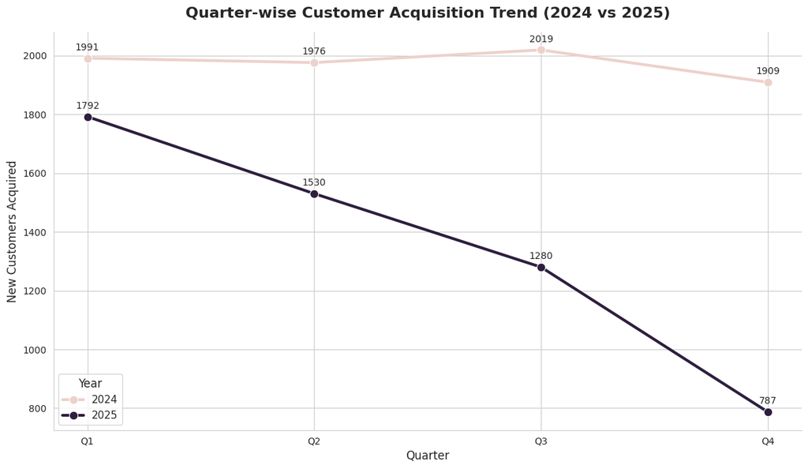

```python
# Better styling
sns.set_style("whitegrid")

plt.figure(figsize=(12, 7))

ax = sns.lineplot(
    data=quarter_wise_performance_data,
    x='signup_quarter',
    y='no_of_customers_acquired',
    hue='signup_year',          # Separate line for each year
    marker='o',
    linewidth=3,
    markersize=9
)

# Add labels to each point
for _, row in quarter_wise_performance_data.iterrows():
    ax.text(
        row['signup_quarter'],
        row['no_of_customers_acquired'] + 20,   # Adjust offset if needed
        f"{row['no_of_customers_acquired']}",
        ha='center',
        va='bottom',
        fontsize=10
    )

# Titles and labels
plt.title(
    "Quarter-wise Customer Acquisition Trend (2024 vs 2025)",
    fontsize=16,
    fontweight='bold',
    pad=15
)

plt.xlabel("Quarter", fontsize=12)
plt.ylabel("New Customers Acquired", fontsize=12)

# Display quarters as Q1, Q2, Q3, Q4
plt.xticks([1, 2, 3, 4], ['Q1', 'Q2', 'Q3', 'Q4'])

# Legend
plt.legend(title="Year", fontsize=11, title_fontsize=12)

# Remove unnecessary borders
sns.despine()

plt.tight_layout()
plt.show()
```

#### We see from the Table that the number of new customers that signed in has a steep decreasing trend. This can be a strong reason behind the revenue decreasing.

```python
import pandas as pd

# Step 1: Build quarter identifiers for signup and orders
df["signup_qid"] = df["signup_year"].astype(str) + "Q" + df["signup_quarter"].astype(str)

df["order_year"] = pd.to_datetime(df["order_date"]).dt.year
df["order_quarter"] = pd.to_datetime(df["order_date"]).dt.quarter
df["order_qid"] = df["order_year"].astype(str) + "Q" + df["order_quarter"].astype(str)

# Step 2: Get new customers per signup quarter
cohorts = df.groupby("signup_qid")["customer_id"].unique()

# Step 3: Get active customers per order quarter
active = df.groupby("order_qid")["customer_id"].unique()

# Step 4: Compute retention
retention_rates = []
quarters = sorted(cohorts.index)

for i in range(len(quarters)-1):
    curr_q = quarters[i]
    next_q = quarters[i+1]

    new_custs = set(cohorts[curr_q])
    next_active = set(active[next_q])

    overlap = len(new_custs.intersection(next_active))
    retention_rate = round((overlap / len(new_custs) if len(new_custs) > 0 else 0)*100)

    retention_rates.append({
        "signup_quarter": curr_q,
        "retention_rate_%": retention_rate
    })

retention_df = pd.DataFrame(retention_rates)

retention_df
```

|  | signup_quarter | retention_rate_% |
| --- | --- | --- |
| 0 | 2024Q1 | 83 |
| 1 | 2024Q2 | 74 |
| 2 | 2024Q3 | 77 |
| 3 | 2024Q4 | 62 |
| 4 | 2025Q1 | 64 |
| 5 | 2025Q2 | 64 |
| 6 | 2025Q3 | 78 |

### Q2. Avg number of orders placed in each quarter ?

```python
quarterly_order_trend = df.groupby(['order_year', 'order_quarter'])['order_id'].count().reset_index(name="no_of_orders")

quarterly_order_trend
```

|  | order_year | order_quarter | no_of_orders |
| --- | --- | --- | --- |
| 0 | 2024 | 1 | 9578 |
| 1 | 2024 | 2 | 10480 |
| 2 | 2024 | 3 | 11769 |
| 3 | 2024 | 4 | 16722 |
| 4 | 2025 | 1 | 11608 |
| 5 | 2025 | 2 | 12552 |
| 6 | 2025 | 3 | 12683 |
| 7 | 2025 | 4 | 14608 |

#### For the Q3 of 2025 where the revenue decreased compared to the same period of last year, the number of orders actually increased. Which means no of orders is not a cause of this decline.

### Q3. Avg Total value of orders placed in each quarter ?

```python
df.columns
```

```
Index(['order_id', 'order_date', 'customer_id', 'customer_signup_date',
       'customer_region', 'customer_gender', 'customer_age',
       'marketing_source', 'loyalty_tier', 'product_id', 'category',
       'subcategory', 'unit_price', 'quantity', 'discount_pct', 'total_amount',
       'channel', 'payment_method', 'delivery_days', 'return_flag',
       'customer_rating', 'signup_year', 'signup_quarter', 'signup_qid',
       'order_year', 'order_quarter', 'order_qid'],
      dtype='object')
```

```python
order_value_for_each_quarter = (
    df.groupby(['order_qid'])['total_amount']
      .agg(total_revenue_of_quarter='sum', average_order_value='mean')
      .reset_index()
)

# Convert revenue to millions
order_value_for_each_quarter['total_revenue_of_quarter_in_millions'] = (
    order_value_for_each_quarter['total_revenue_of_quarter'] / 1_000_000
).round(2)
```

```python
order_value_for_each_quarter
```

|  | order_qid | total_revenue_of_quarter | average_order_value | total_revenue_of_quarter_in_millions |
| --- | --- | --- | --- | --- |
| 0 | 2024Q1 | 1214349.78 | 126.785318 | 1.21 |
| 1 | 2024Q2 | 1327153.51 | 126.636785 | 1.33 |
| 2 | 2024Q3 | 1473921.12 | 125.237583 | 1.47 |
| 3 | 2024Q4 | 2099151.18 | 125.532304 | 2.10 |
| 4 | 2025Q1 | 1466308.13 | 126.318757 | 1.47 |
| 5 | 2025Q2 | 1577820.38 | 125.702707 | 1.58 |
| 6 | 2025Q3 | 1248048.83 | 98.403282 | 1.25 |
| 7 | 2025Q4 | 1469908.49 | 100.623528 | 1.47 |

[figure not shown]

```python
# plt.figure(figsize=(12,4))

# sns.lineplot(
#   data=order_value_for_each_quarter,
#   x='order_qid',
#   y='average_order_value'
# )


# Professional styling
sns.set_theme(style="whitegrid", context="talk")

plt.figure(figsize=(12,6))

ax = sns.lineplot(
    data=order_value_for_each_quarter,
    x='order_qid',
    y='average_order_value',
    marker='o',
    linewidth=3,
    markersize=10,
    color='#1f77b4'
)

# Add value labels
for _, row in order_value_for_each_quarter.iterrows():
    ax.annotate(
        f"{row['average_order_value']:.2f}",
        (row['order_qid'], row['average_order_value']),
        textcoords="offset points",
        xytext=(0,10),
        ha='center',
        fontsize=10
    )

# Custom x-axis labels
plt.xticks(
    ticks=range(1,9),
    labels=[
        '2024-Q1','2024-Q2','2024-Q3','2024-Q4',
        '2025-Q1','2025-Q2','2025-Q3','2025-Q4'
    ],
    rotation=30
)

plt.title(
    "Quarter-wise Average Order Value (AOV)",
    fontsize=18,
    fontweight='bold',
    pad=15
)

plt.xlabel("Quarter", fontsize=13)
plt.ylabel("Average Order Value (₹)", fontsize=13)

plt.grid(axis='y', linestyle='--', alpha=0.5)

sns.despine()

plt.tight_layout()
plt.show()
```

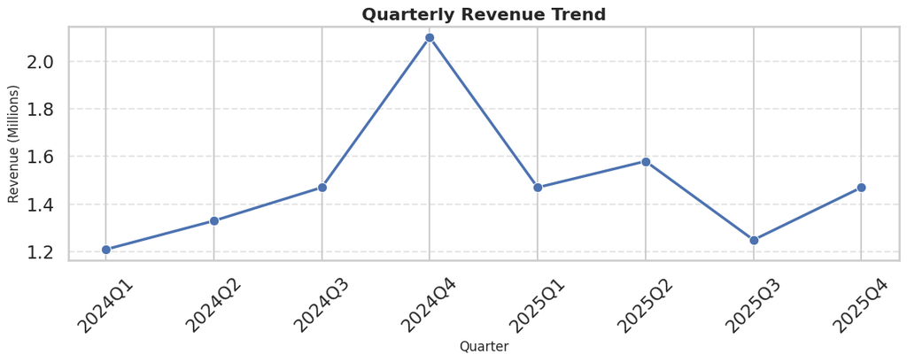

```python
# plt.figure(figsize=(12,4))

# sns.lineplot(
#     data=order_value_for_each_quarter,
#     x='order_qid',
#     y='total_revenue_of_quarter_in_millions'
# )

plt.figure(figsize=(12, 5))

sns.lineplot(
    data=order_value_for_each_quarter,
    x="order_qid",
    y="total_revenue_of_quarter_in_millions",
    marker="o",
    linewidth=2.5
)

plt.title("Quarterly Revenue Trend", fontsize=16, fontweight="bold")
plt.xlabel("Quarter", fontsize=12)
plt.ylabel("Revenue (Millions)", fontsize=12)

plt.xticks(rotation=45)
plt.grid(axis="y", linestyle="--", alpha=0.5)

plt.tight_layout()
plt.show()
```

#### In the quarter 3 the number of orders increased but the average order value (AOV) of the quarter decreased. So this can be a factor of decline in the revenue. We will investigate this as well.

### Now We will state our hypothesis:

1. Average Order Value dropped dramatically in the Q3 of 2025.
2. Customer Acquisition has steadily declined.

#### We will look at each of them one by one.

#### I. Heavy Decrement in Average Order Value

```python
df.head()
```

|  | order_id | order_date | customer_id | customer_signup_date | customer_region | customer_gender | customer_age | marketing_source | loyalty_tier | product_id | ... | payment_method | delivery_days | return_flag | customer_rating | signup_year | signup_quarter | signup_qid | order_year | order_quarter | order_qid |
| --- | --- | --- | --- | --- | --- | --- | --- | --- | --- | --- | --- | --- | --- | --- | --- | --- | --- | --- | --- | --- | --- |
| 0 | ORD585279 | 2024-01-01 | CUST112178 | 2024-01-26 | South | Male | 18 | Referral | High | P0142 | ... | Credit Card | 3 | 0 | 4 | 2024 | 1 | 2024Q1 | 2024 | 1 | 2024Q1 |
| 1 | ORD594380 | 2024-01-01 | CUST112083 | 2024-01-05 | South | Female | 56 | Social Media | Medium | P0131 | ... | UPI/Net Banking | 2 | 0 | 5 | 2024 | 1 | 2024Q1 | 2024 | 1 | 2024Q1 |
| 2 | ORD552020 | 2024-01-01 | CUST114370 | 2024-01-28 | North | Male | 33 | Paid Ads | Medium | P0052 | ... | Credit Card | 5 | 0 | 3 | 2024 | 1 | 2024Q1 | 2024 | 1 | 2024Q1 |
| 3 | ORD522721 | 2024-01-01 | CUST103632 | 2024-01-28 | South | Female | 60 | Referral | Medium | P0105 | ... | Credit Card | 4 | 0 | 4 | 2024 | 1 | 2024Q1 | 2024 | 1 | 2024Q1 |
| 4 | ORD578390 | 2024-01-01 | CUST106615 | 2024-01-19 | North | Male | 39 | Organic Search | Low | P0145 | ... | Credit Card | 2 | 0 | 5 | 2024 | 1 | 2024Q1 | 2024 | 1 | 2024Q1 |

5 rows × 27 columns

```python
df.columns
```

```
Index(['order_id', 'order_date', 'customer_id', 'customer_signup_date',
       'customer_region', 'customer_gender', 'customer_age',
       'marketing_source', 'loyalty_tier', 'product_id', 'category',
       'subcategory', 'unit_price', 'quantity', 'discount_pct', 'total_amount',
       'channel', 'payment_method', 'delivery_days', 'return_flag',
       'customer_rating', 'signup_year', 'signup_quarter', 'signup_qid',
       'order_year', 'order_quarter', 'order_qid'],
      dtype='object')
```

#### What can be the possible reasons contributing to this decrease ?

1. Is the category of products being ordered in the third quarter of 2025 same as the categories from 2024 ?
2. Has the average number of items in the orders decreased ?
3. Was there any change in the unit price of the items ?
4. What is the change in discount that was being given to the customers ?

#### Q1. Is the category of products being ordered in the third quarter of 2025 same as the categories from 2024 ?

```python
q3_2024_data = df[(df['order_quarter'] == 3) & (df['order_year'] == 2024)]

pdt_cats_Q3_2024 = q3_2024_data.groupby(['order_qid','category'])['order_id'].count().reset_index(name="no_of_orders")

pdt_cats_Q3_2024
```

|  | order_qid | category | no_of_orders |
| --- | --- | --- | --- |
| 0 | 2024Q3 | Beauty | 2022 |
| 1 | 2024Q3 | Books & Media | 1984 |
| 2 | 2024Q3 | Electronics | 1893 |
| 3 | 2024Q3 | Fashion | 1970 |
| 4 | 2024Q3 | Home & Kitchen | 1937 |
| 5 | 2024Q3 | Sports & Outdoors | 1963 |

```python
q3_2025_data = df[(df['order_quarter'] == 3) & (df['order_year'] == 2025)]

pdt_cats_Q3_2025 = q3_2025_data.groupby(['order_qid','category'])['order_id'].count().reset_index(name="no_of_orders")

pdt_cats_Q3_2025
```

|  | order_qid | category | no_of_orders |
| --- | --- | --- | --- |
| 0 | 2025Q3 | Beauty | 2183 |
| 1 | 2025Q3 | Books & Media | 2148 |
| 2 | 2025Q3 | Electronics | 2069 |
| 3 | 2025Q3 | Fashion | 2056 |
| 4 | 2025Q3 | Home & Kitchen | 2106 |
| 5 | 2025Q3 | Sports & Outdoors | 2121 |

```python
q3_overall_category_data = pd.concat([pdt_cats_Q3_2024 , pdt_cats_Q3_2025])

q3_overall_category_data
```

|  | order_qid | category | no_of_orders |
| --- | --- | --- | --- |
| 0 | 2024Q3 | Beauty | 2022 |
| 1 | 2024Q3 | Books & Media | 1984 |
| 2 | 2024Q3 | Electronics | 1893 |
| 3 | 2024Q3 | Fashion | 1970 |
| 4 | 2024Q3 | Home & Kitchen | 1937 |
| 5 | 2024Q3 | Sports & Outdoors | 1963 |
| 0 | 2025Q3 | Beauty | 2183 |
| 1 | 2025Q3 | Books & Media | 2148 |
| 2 | 2025Q3 | Electronics | 2069 |
| 3 | 2025Q3 | Fashion | 2056 |
| 4 | 2025Q3 | Home & Kitchen | 2106 |
| 5 | 2025Q3 | Sports & Outdoors | 2121 |

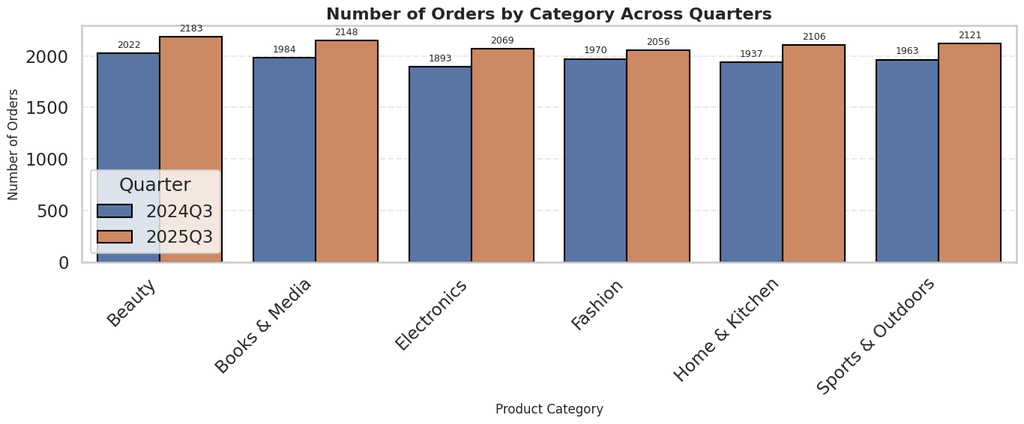

```python
# plt.figure(figsize=(12,6))

# ax = sns.barplot(
#     data=q3_overall_category_data,
#     x='category',
#     y='no_of_orders',
#     hue='order_qid'
# )

# for container in ax.containers:
#   ax.bar_label(container)

plt.figure(figsize=(14, 6))

ax = sns.barplot(
    data=q3_overall_category_data,
    x="category",
    y="no_of_orders",
    hue="order_qid",
    edgecolor="black"
)

# Add value labels
for container in ax.containers:
    ax.bar_label(container, fontsize=9, padding=3)

# Titles and labels
plt.title("Number of Orders by Category Across Quarters",
          fontsize=16, fontweight="bold")
plt.xlabel("Product Category", fontsize=12)
plt.ylabel("Number of Orders", fontsize=12)

# Improve readability
plt.xticks(rotation=45, ha="right")
plt.legend(title="Quarter", frameon=True)
plt.grid(axis="y", linestyle="--", alpha=0.4)

plt.tight_layout()
plt.show()
```

##### Categories remains the same. So The issue is not in the categories. Infact in each category the number of orders increased.

#### Q2. Has the average number of items in orders changed ?

```python
df.head()
```

|  | order_id | order_date | customer_id | customer_signup_date | customer_region | customer_gender | customer_age | marketing_source | loyalty_tier | product_id | ... | payment_method | delivery_days | return_flag | customer_rating | signup_year | signup_quarter | signup_qid | order_year | order_quarter | order_qid |
| --- | --- | --- | --- | --- | --- | --- | --- | --- | --- | --- | --- | --- | --- | --- | --- | --- | --- | --- | --- | --- | --- |
| 0 | ORD585279 | 2024-01-01 | CUST112178 | 2024-01-26 | South | Male | 18 | Referral | High | P0142 | ... | Credit Card | 3 | 0 | 4 | 2024 | 1 | 2024Q1 | 2024 | 1 | 2024Q1 |
| 1 | ORD594380 | 2024-01-01 | CUST112083 | 2024-01-05 | South | Female | 56 | Social Media | Medium | P0131 | ... | UPI/Net Banking | 2 | 0 | 5 | 2024 | 1 | 2024Q1 | 2024 | 1 | 2024Q1 |
| 2 | ORD552020 | 2024-01-01 | CUST114370 | 2024-01-28 | North | Male | 33 | Paid Ads | Medium | P0052 | ... | Credit Card | 5 | 0 | 3 | 2024 | 1 | 2024Q1 | 2024 | 1 | 2024Q1 |
| 3 | ORD522721 | 2024-01-01 | CUST103632 | 2024-01-28 | South | Female | 60 | Referral | Medium | P0105 | ... | Credit Card | 4 | 0 | 4 | 2024 | 1 | 2024Q1 | 2024 | 1 | 2024Q1 |
| 4 | ORD578390 | 2024-01-01 | CUST106615 | 2024-01-19 | North | Male | 39 | Organic Search | Low | P0145 | ... | Credit Card | 2 | 0 | 5 | 2024 | 1 | 2024Q1 | 2024 | 1 | 2024Q1 |

5 rows × 27 columns

```python
q3_2024_order_items = round(q3_2024_data['quantity'].mean())

print(f"The avg number of items in each order in Q3 of 2024 was: ", q3_2024_order_items)
```

```
The avg number of items in each order in Q3 of 2024 was:  2
```

```python
q3_2025_order_items = round(q3_2025_data['quantity'].mean())

print(f"The avg number of items in each order in Q3 of 2025 was: ", q3_2025_order_items)
```

```
The avg number of items in each order in Q3 of 2025 was:  2
```

##### There is no change in the Avg number of items in an order for both the quarters. So this cant be the cause.

#### Q3. Was There any change in the unit price of the items ?

```python
q3_2024_unit_price = round(q3_2024_data['unit_price'].mean(),2)

print(f"The avg unit price of orders in Q3 of 2024 was: ", q3_2024_unit_price)
```

```
The avg unit price of orders in Q3 of 2024 was:  66.89
```

```python
q3_2025_unit_price = round(q3_2025_data['unit_price'].mean(),2)

print(f"The avg unit price of orders in Q3 of 2024 was: ", q3_2025_unit_price)
```

```
The avg unit price of orders in Q3 of 2024 was:  66.66
```

#### Again, We dont see any considerable difference in the average unit prices.

#### Q4. What is the change in discount that was being given to the customers ?

```python
q3_2024_discount = round(q3_2024_data['discount_pct'].mean(),2)

print(f"The Average discount % given on the orders in Q3 of 2024 was: {q3_2024_discount}")
```

```
The Average discount % given on the orders in Q3 of 2024 was: 6.05
```

```python
q3_2025_discount = round(q3_2025_data['discount_pct'].mean(),2)

print(f"The Average discount % given on the orders in Q3 of 2024 was: {q3_2025_discount}")
```

```
The Average discount % given on the orders in Q3 of 2024 was: 22.03
```

#### We Found the culprit here. The average discount percentage that was being given to customers in quarter 3 of 2025 was 22% which is about 16% more than the average discount percentage that was given in quarter 3 of 2024. This is the reason the revenue dropped significantly even when the number of orders increased.

```python
# Lets first understand what was the trend in average discount rate given.

overall_discount_pct = df.groupby(['order_year', 'order_quarter'])['discount_pct'].mean().reset_index()
overall_discount_pct
```

|  | order_year | order_quarter | discount_pct |
| --- | --- | --- | --- |
| 0 | 2024 | 1 | 6.061338 |
| 1 | 2024 | 2 | 5.993101 |
| 2 | 2024 | 3 | 6.047362 |
| 3 | 2024 | 4 | 5.929386 |
| 4 | 2025 | 1 | 5.973432 |
| 5 | 2025 | 2 | 6.022020 |
| 6 | 2025 | 3 | 22.028408 |
| 7 | 2025 | 4 | 22.381921 |

##### We see here that the discount was stable until third quarter of 2025 where it increased abnormally and increased further in the last quarter of 2025.

```python
# Which categories the discount was given more suddenly:

category_wise_discount = df.groupby(['order_qid', 'category'])['discount_pct'].mean().reset_index().sort_values(by=['category','order_qid'], ascending=[True, True])
category_wise_discount['discount_pct'] = round(category_wise_discount['discount_pct'],2)

category_wise_discount
```

|  | order_qid | category | discount_pct |
| --- | --- | --- | --- |
| 0 | 2024Q1 | Beauty | 5.99 |
| 6 | 2024Q2 | Beauty | 6.00 |
| 12 | 2024Q3 | Beauty | 6.11 |
| 18 | 2024Q4 | Beauty | 5.98 |
| 24 | 2025Q1 | Beauty | 5.94 |
| 30 | 2025Q2 | Beauty | 6.05 |
| 36 | 2025Q3 | Beauty | 21.89 |
| 42 | 2025Q4 | Beauty | 22.36 |
| 1 | 2024Q1 | Books & Media | 6.07 |
| 7 | 2024Q2 | Books & Media | 6.00 |
| 13 | 2024Q3 | Books & Media | 6.05 |
| 19 | 2024Q4 | Books & Media | 5.92 |
| 25 | 2025Q1 | Books & Media | 6.01 |
| 31 | 2025Q2 | Books & Media | 5.90 |
| 37 | 2025Q3 | Books & Media | 21.99 |
| 43 | 2025Q4 | Books & Media | 22.26 |
| 2 | 2024Q1 | Electronics | 6.04 |
| 8 | 2024Q2 | Electronics | 6.00 |
| 14 | 2024Q3 | Electronics | 6.06 |
| 20 | 2024Q4 | Electronics | 5.93 |
| 26 | 2025Q1 | Electronics | 5.95 |
| 32 | 2025Q2 | Electronics | 5.99 |
| 38 | 2025Q3 | Electronics | 21.98 |
| 44 | 2025Q4 | Electronics | 22.32 |
| 3 | 2024Q1 | Fashion | 6.13 |
| 9 | 2024Q2 | Fashion | 5.98 |
| 15 | 2024Q3 | Fashion | 5.97 |
| 21 | 2024Q4 | Fashion | 5.95 |
| 27 | 2025Q1 | Fashion | 5.99 |
| 33 | 2025Q2 | Fashion | 6.13 |
| 39 | 2025Q3 | Fashion | 22.28 |
| 45 | 2025Q4 | Fashion | 22.46 |
| 4 | 2024Q1 | Home & Kitchen | 6.16 |
| 10 | 2024Q2 | Home & Kitchen | 5.91 |
| 16 | 2024Q3 | Home & Kitchen | 6.09 |
| 22 | 2024Q4 | Home & Kitchen | 5.93 |
| 28 | 2025Q1 | Home & Kitchen | 6.02 |
| 34 | 2025Q2 | Home & Kitchen | 5.95 |
| 40 | 2025Q3 | Home & Kitchen | 21.94 |
| 46 | 2025Q4 | Home & Kitchen | 22.45 |
| 5 | 2024Q1 | Sports & Outdoors | 5.96 |
| 11 | 2024Q2 | Sports & Outdoors | 6.09 |
| 17 | 2024Q3 | Sports & Outdoors | 6.00 |
| 23 | 2024Q4 | Sports & Outdoors | 5.87 |
| 29 | 2025Q1 | Sports & Outdoors | 5.92 |
| 35 | 2025Q2 | Sports & Outdoors | 6.10 |
| 41 | 2025Q3 | Sports & Outdoors | 22.10 |
| 47 | 2025Q4 | Sports & Outdoors | 22.46 |

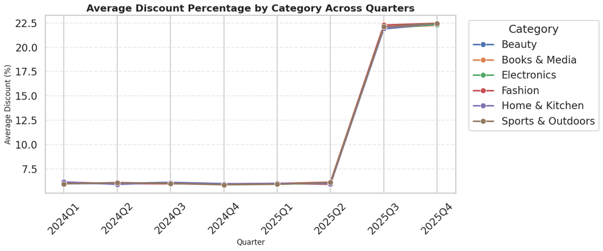

```python
# plt.figure(figsize=(12,6))


# sns.lineplot(
#     data=category_wise_discount,
#     x="order_qid",
#     y='discount_pct',
#     hue="category"
# )

plt.figure(figsize=(14, 6))

sns.lineplot(
    data=category_wise_discount,
    x="order_qid",
    y="discount_pct",
    hue="category",
    marker="o",
    linewidth=2.5
)

# Titles and labels
plt.title("Average Discount Percentage by Category Across Quarters",
          fontsize=16, fontweight="bold")
plt.xlabel("Quarter", fontsize=12)
plt.ylabel("Average Discount (%)", fontsize=12)

# Improve readability
plt.xticks(rotation=45)
plt.grid(axis="y", linestyle="--", alpha=0.4)

# Legend
plt.legend(
    title="Category",
    bbox_to_anchor=(1.02, 1),
    loc="upper left",
    frameon=True
)

plt.tight_layout()
plt.show()
```

#### For each of the category the discount percentage was increased to almost 22% in the third quarter of 2025. So This is not specific to a category.

```python
category_wise_discount = (
    df.groupby(['order_year', 'order_quarter', 'category'])
      .agg(
          mean_discount=('discount_pct', 'mean'),
          order_count=('order_id', 'count')
      )
      .reset_index()
      .sort_values(by=['category','order_year','order_quarter'], ascending=[True, True, True])
)

print(category_wise_discount)
```

```
    order_year  order_quarter           category  mean_discount  order_count
0         2024              1             Beauty       5.994824         1565
6         2024              2             Beauty       5.995300         1766
12        2024              3             Beauty       6.105687         2022
18        2024              4             Beauty       5.976225         2877
24        2025              1             Beauty       5.941048         1927
30        2025              2             Beauty       6.050743         2085
36        2025              3             Beauty      21.894961         2183
42        2025              4             Beauty      22.359558         2354
1         2024              1      Books & Media       6.073949         1593
7         2024              2      Books & Media       6.002549         1687
13        2024              3      Books & Media       6.053327         1984
19        2024              4      Books & Media       5.915120         2705
25        2025              1      Books & Media       6.009600         1927
31        2025              2      Books & Media       5.901280         2109
```

[output cut: 34 more lines]

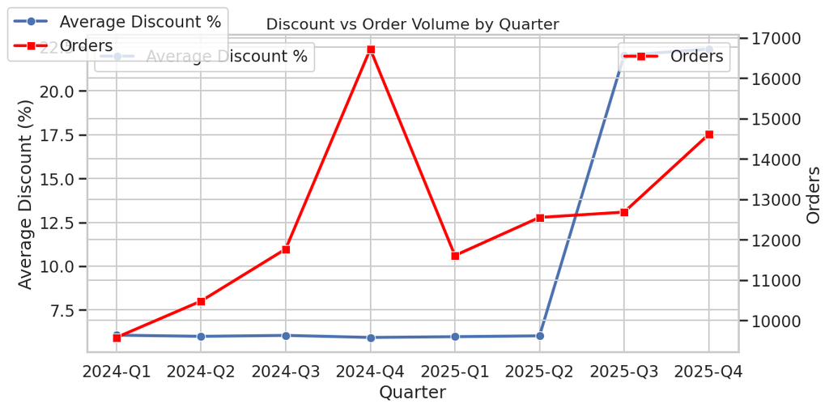

```python
# Aggregate over all categories
quarter_discount = (
    category_wise_discount
    .groupby(['order_year', 'order_quarter'])
    .agg(
        avg_discount=('mean_discount', 'mean'),
        total_orders=('order_count', 'sum')
    )
    .reset_index()
)

quarter_discount['Quarter'] = (
    quarter_discount['order_year'].astype(str)
    + '-Q' +
    quarter_discount['order_quarter'].astype(str)
)

fig, ax1 = plt.subplots(figsize=(12,6))

sns.lineplot(
    data=quarter_discount,
    x='Quarter',
    y='avg_discount',
    marker='o',
    linewidth=3,
    ax=ax1,
    label='Average Discount %'
)

ax1.set_ylabel("Average Discount (%)")

ax2 = ax1.twinx()

sns.lineplot(
    data=quarter_discount,
    x='Quarter',
    y='total_orders',
    marker='s',
    linewidth=3,
    color='red',
    ax=ax2,
    label='Orders'
)

ax2.set_ylabel("Orders")

plt.title("Discount vs Order Volume by Quarter", fontsize=16)

fig.legend(loc='upper left')

plt.tight_layout()
plt.show()
```

#### The discounts were not very effective in terms of no of orders.

```python
corr = round(category_wise_discount['mean_discount'].corr(
    category_wise_discount['order_count']
),2)

print(f"The relationship between discount percent and no of orders is: {corr}. Which is less than moderate relationship strength.")
```

```
The relationship between discount percent and no of orders is: 0.31. Which is less than moderate relationship strength.
```

```python
df.columns
```

```
Index(['order_id', 'order_date', 'customer_id', 'customer_signup_date',
       'customer_region', 'customer_gender', 'customer_age',
       'marketing_source', 'loyalty_tier', 'product_id', 'category',
       'subcategory', 'unit_price', 'quantity', 'discount_pct', 'total_amount',
       'channel', 'payment_method', 'delivery_days', 'return_flag',
       'customer_rating', 'signup_year', 'signup_quarter', 'signup_qid',
       'order_year', 'order_quarter', 'order_qid'],
      dtype='object')
```

```python
# Was discount given to specific customers segments or all of them equally.

loyalty_wise_discounts = df.groupby(['order_year', 'order_quarter', 'loyalty_tier'])['discount_pct'].mean().reset_index().sort_values(by=['loyalty_tier','order_year', 'order_quarter'], ascending=[True, True, True])

loyalty_wise_discounts
```

|  | order_year | order_quarter | loyalty_tier | discount_pct |
| --- | --- | --- | --- | --- |
| 0 | 2024 | 1 | High | 6.068287 |
| 3 | 2024 | 2 | High | 6.011343 |
| 6 | 2024 | 3 | High | 6.011268 |
| 9 | 2024 | 4 | High | 5.940409 |
| 12 | 2025 | 1 | High | 5.971326 |
| 15 | 2025 | 2 | High | 5.979709 |
| 18 | 2025 | 3 | High | 22.055386 |
| 21 | 2025 | 4 | High | 22.364215 |
| 1 | 2024 | 1 | Low | 6.048258 |
| 4 | 2024 | 2 | Low | 5.944536 |
| 7 | 2024 | 3 | Low | 6.099843 |
| 10 | 2024 | 4 | Low | 5.958106 |
| 13 | 2025 | 1 | Low | 5.931408 |
| 16 | 2025 | 2 | Low | 6.071071 |
| 19 | 2025 | 3 | Low | 22.116078 |
| 22 | 2025 | 4 | Low | 22.432526 |
| 2 | 2024 | 1 | Medium | 6.061287 |
| 5 | 2024 | 2 | Medium | 6.000000 |
| 8 | 2024 | 3 | Medium | 6.057325 |
| 11 | 2024 | 4 | Medium | 5.901279 |
| 14 | 2025 | 1 | Medium | 5.999680 |
| 17 | 2025 | 2 | Medium | 6.036308 |
| 20 | 2025 | 3 | Medium | 21.949094 |
| 23 | 2025 | 4 | Medium | 22.372151 |

#### The discount percent is almost same for all tier groups in the data.

#### Insight:

NimbusMart adopted a broad-based discount strategy in Q3 2025. However, the increase in discounts did not generate proportional growth in order volume or customer acquisition. Instead, it coincided with a decline in Average Order Value and overall revenue, suggesting the strategy eroded revenue more than it stimulated demand.

#### **II. Customer Acquisition dropped significantly.**

#### Now instead of formulating questions here. Lets find out using the data.

#### Q1. What are the unique marketing sources ?

```python
df['marketing_source'].unique()
```

```
array(['Referral', 'Social Media', 'Paid Ads', 'Organic Search', 'Email'],
      dtype=object)
```

#### Q2. How is the performance of each source in each quarter ?

```python
df.columns
```

```
Index(['order_id', 'order_date', 'customer_id', 'customer_signup_date',
       'customer_region', 'customer_gender', 'customer_age',
       'marketing_source', 'loyalty_tier', 'product_id', 'category',
       'subcategory', 'unit_price', 'quantity', 'discount_pct', 'total_amount',
       'channel', 'payment_method', 'delivery_days', 'return_flag',
       'customer_rating', 'signup_year', 'signup_quarter', 'signup_qid',
       'order_year', 'order_quarter', 'order_qid'],
      dtype='object')
```

```python
marketing_source_overall_performance_data = df[['signup_year', 'signup_quarter','signup_qid', 'marketing_source', 'customer_id']]

marketing_source_overall_performance = marketing_source_overall_performance_data.groupby(['signup_qid', 'marketing_source',])['customer_id'].nunique().reset_index(name="no_of_customers_acquired")
```

[figure not shown]

```python
# Professional theme
sns.set_theme(style="whitegrid", context="talk")

plt.figure(figsize=(14, 7))

ax = sns.lineplot(
    data=marketing_source_overall_performance,
    x='signup_qid',
    y='no_of_customers_acquired',
    hue='marketing_source',
    marker='o',
    linewidth=3,
    markersize=10
)

# Add labels to each point
for _, row in marketing_source_overall_performance.iterrows():
    ax.annotate(
        text=f"{int(row['no_of_customers_acquired'])}",
        xy=(row['signup_qid'], row['no_of_customers_acquired']),
        xytext=(0, 8),
        textcoords='offset points',
        ha='center',
        fontsize=9
    )

# Custom x-axis labels
plt.xticks(
    ticks=range(1, 9),
    labels=[
        '2024-Q1', '2024-Q2', '2024-Q3', '2024-Q4',
        '2025-Q1', '2025-Q2', '2025-Q3', '2025-Q4'
    ]
)

# Titles
plt.title(
    "Quarter-wise Customer Acquisition by Marketing Source",
    fontsize=18,
    fontweight='bold',
    pad=15
)

plt.xlabel("Quarter", fontsize=13)
plt.ylabel("New Customers Acquired", fontsize=13)

# Improve legend
plt.legend(
    title='Marketing Source',
    title_fontsize=12,
    fontsize=11,
    loc='upper left',
    bbox_to_anchor=(1.02, 1),
    frameon=True
)

# Grid styling
plt.grid(axis='y', linestyle='--', alpha=0.5)

# Remove top/right borders
sns.despine()

plt.tight_layout()
plt.show()
```

#### The customer acquisition remained stable until the end of first year, but started decreasing from the beginning of the second year.

#### Q3. What is comparison of Q3 2024 performance of marketing sources to Q3 2025 performance of marketing sources.

```python
quarter_2024_source_performance = df[(df['signup_quarter'] == 3) & (df['signup_year'] == 2024)].groupby(['signup_year', 'signup_quarter', 'marketing_source'])['customer_id'].nunique().reset_index(name="no_of_new_customers_acquired_2024")
quarter_2024_source_performance
```

|  | signup_year | signup_quarter | marketing_source | no_of_new_customers_acquired_2024 |
| --- | --- | --- | --- | --- |
| 0 | 2024 | 3 | Email | 248 |
| 1 | 2024 | 3 | Organic Search | 627 |
| 2 | 2024 | 3 | Paid Ads | 559 |
| 3 | 2024 | 3 | Referral | 271 |
| 4 | 2024 | 3 | Social Media | 314 |

```python
quarter_2025_source_performance = df[(df['signup_quarter'] == 3) & (df['signup_year'] == 2025)].groupby(['signup_year', 'signup_quarter', 'marketing_source'])['customer_id'].nunique().reset_index(name="no_of_new_customers_acquired_2025")
quarter_2025_source_performance
```

|  | signup_year | signup_quarter | marketing_source | no_of_new_customers_acquired_2025 |
| --- | --- | --- | --- | --- |
| 0 | 2025 | 3 | Email | 157 |
| 1 | 2025 | 3 | Organic Search | 391 |
| 2 | 2025 | 3 | Paid Ads | 335 |
| 3 | 2025 | 3 | Referral | 195 |
| 4 | 2025 | 3 | Social Media | 202 |

```python
final_acquisition_table = quarter_2024_source_performance.merge(
    quarter_2025_source_performance[['marketing_source','no_of_new_customers_acquired_2025']],
    on=['marketing_source'],
    how='inner'
)

final_acquisition_table
```

|  | signup_year | signup_quarter | marketing_source | no_of_new_customers_acquired_2024 | no_of_new_customers_acquired_2025 |
| --- | --- | --- | --- | --- | --- |
| 0 | 2024 | 3 | Email | 248 | 157 |
| 1 | 2024 | 3 | Organic Search | 627 | 391 |
| 2 | 2024 | 3 | Paid Ads | 559 | 335 |
| 3 | 2024 | 3 | Referral | 271 | 195 |
| 4 | 2024 | 3 | Social Media | 314 | 202 |

```python
plot_df = final_acquisition_table.melt(
    id_vars='marketing_source',
    value_vars=[
        'no_of_new_customers_acquired_2024',
        'no_of_new_customers_acquired_2025'
    ],
    var_name='Year',
    value_name='New Customers'
)

plot_df['Year'] = plot_df['Year'].str[-4:]
```

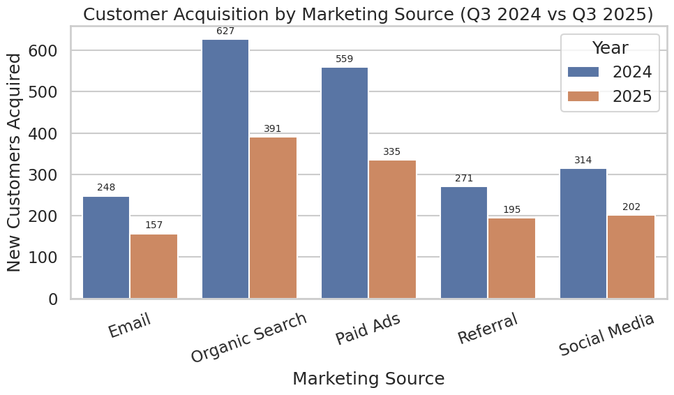

```python
plt.figure(figsize=(10,6))

ax = sns.barplot(
    data=plot_df,
    x='marketing_source',
    y='New Customers',
    hue='Year'
)

# Add labels on each bar
for container in ax.containers:
    ax.bar_label(
        container,
        fmt='%d',
        padding=3,
        fontsize=10
    )

plt.title("Customer Acquisition by Marketing Source (Q3 2024 vs Q3 2025)")
plt.xlabel("Marketing Source")
plt.ylabel("New Customers Acquired")
plt.xticks(rotation=20)
plt.legend(title='Year')

plt.tight_layout()
plt.show()
```

##### Insight:

- We can clearly notice that each of the marketing source is performing poor in the Q3 of 2025 compared to the same quarter of previous year.

#### **What to do then ?**

```python
df.head().T
```

|  | 0 | 1 | 2 | 3 | 4 |
| --- | --- | --- | --- | --- | --- |
| order_id | ORD585279 | ORD594380 | ORD552020 | ORD522721 | ORD578390 |
| order_date | 2024-01-01 00:00:00 | 2024-01-01 00:00:00 | 2024-01-01 00:00:00 | 2024-01-01 00:00:00 | 2024-01-01 00:00:00 |
| customer_id | CUST112178 | CUST112083 | CUST114370 | CUST103632 | CUST106615 |
| customer_signup_date | 2024-01-26 00:00:00 | 2024-01-05 00:00:00 | 2024-01-28 00:00:00 | 2024-01-28 00:00:00 | 2024-01-19 00:00:00 |
| customer_region | South | South | North | South | North |
| customer_gender | Male | Female | Male | Female | Male |
| customer_age | 18 | 56 | 33 | 60 | 39 |
| marketing_source | Referral | Social Media | Paid Ads | Referral | Organic Search |
| loyalty_tier | High | Medium | Medium | Medium | Low |
| product_id | P0142 | P0131 | P0052 | P0105 | P0145 |
| category | Sports & Outdoors | Sports & Outdoors | Home & Kitchen | Beauty | Sports & Outdoors |
| subcategory | Cycling Accessories | Yoga | Decor | Makeup | Sportswear |
| unit_price | 141.5 | 48.39 | 134.5 | 60.75 | 116.6 |
| quantity | 2 | 1 | 1 | 1 | 2 |
| discount_pct | 2.4 | 11.9 | 4.3 | 7.2 | 2.5 |
| total_amount | 276.21 | 42.63 | 128.72 | 56.38 | 227.37 |
| channel | Website | Website | Website | Mobile App | Website |
| payment_method | Credit Card | UPI/Net Banking | Credit Card | Credit Card | Credit Card |
| delivery_days | 3 | 2 | 5 | 4 | 2 |
| return_flag | 0 | 0 | 0 | 0 | 0 |
| customer_rating | 4 | 5 | 3 | 4 | 5 |
| signup_year | 2024 | 2024 | 2024 | 2024 | 2024 |
| signup_quarter | 1 | 1 | 1 | 1 | 1 |
| signup_qid | 2024Q1 | 2024Q1 | 2024Q1 | 2024Q1 | 2024Q1 |
| order_year | 2024 | 2024 | 2024 | 2024 | 2024 |
| order_quarter | 1 | 1 | 1 | 1 | 1 |
| order_qid | 2024Q1 | 2024Q1 | 2024Q1 | 2024Q1 | 2024Q1 |

```python
df.columns
```

```
Index(['order_id', 'order_date', 'customer_id', 'customer_signup_date',
       'customer_region', 'customer_gender', 'customer_age',
       'marketing_source', 'loyalty_tier', 'product_id', 'category',
       'subcategory', 'unit_price', 'quantity', 'discount_pct', 'total_amount',
       'channel', 'payment_method', 'delivery_days', 'return_flag',
       'customer_rating', 'signup_year', 'signup_quarter', 'signup_qid',
       'order_year', 'order_quarter', 'order_qid'],
      dtype='object')
```

#### We will convert the universal discount strategy into segmented strategies for different segments.

- We will analyze and create different strategies for different customer segments like following in this order:
  1. Loyalty tier
  2. Marketing Source
  3. Product Categories
  4. Region of the customer.
  5. Sales Channel

##### Loyalty Tier Startegy

```python
# Loyalty tier

loyalty_wise_data = df.groupby(['order_qid', 'loyalty_tier'])['order_id'].count().reset_index(name="no_of_orders").sort_values(by=['loyalty_tier','order_qid'])

loyalty_wise_data
```

|  | order_qid | loyalty_tier | no_of_orders |
| --- | --- | --- | --- |
| 0 | 2024Q1 | High | 3970 |
| 3 | 2024Q2 | High | 4364 |
| 6 | 2024Q3 | High | 4899 |
| 9 | 2024Q4 | High | 6798 |
| 12 | 2025Q1 | High | 4743 |
| 15 | 2025Q2 | High | 4884 |
| 18 | 2025Q3 | High | 5106 |
| 21 | 2025Q4 | High | 5874 |
| 1 | 2024Q1 | Low | 2095 |
| 4 | 2024Q2 | Low | 2196 |
| 7 | 2024Q3 | Low | 2549 |
| 10 | 2024Q4 | Low | 3590 |
| 13 | 2025Q1 | Low | 2493 |
| 16 | 2025Q2 | Low | 2793 |
| 19 | 2025Q3 | Low | 2774 |
| 22 | 2025Q4 | Low | 3136 |
| 2 | 2024Q1 | Medium | 3513 |
| 5 | 2024Q2 | Medium | 3920 |
| 8 | 2024Q3 | Medium | 4321 |
| 11 | 2024Q4 | Medium | 6334 |
| 14 | 2025Q1 | Medium | 4372 |
| 17 | 2025Q2 | Medium | 4875 |
| 20 | 2025Q3 | Medium | 4803 |
| 23 | 2025Q4 | Medium | 5598 |

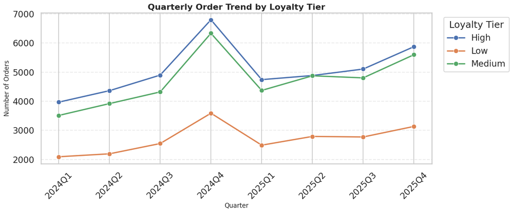

```python
# plt.figure(figsize=(12,6))


# sns.lineplot(
#     data=loyalty_wise_data,
#     x='order_qid',
#     y='no_of_orders',
#     hue='loyalty_tier'
# )

plt.figure(figsize=(14, 6))

sns.lineplot(
    data=loyalty_wise_data,
    x="order_qid",
    y="no_of_orders",
    hue="loyalty_tier",
    marker="o",
    linewidth=2.5
)

# Title and labels
plt.title(
    "Quarterly Order Trend by Loyalty Tier",
    fontsize=16,
    fontweight="bold"
)
plt.xlabel("Quarter", fontsize=12)
plt.ylabel("Number of Orders", fontsize=12)

# Improve readability
plt.xticks(rotation=45)
plt.grid(axis="y", linestyle="--", alpha=0.4)

# Legend
plt.legend(
    title="Loyalty Tier",
    bbox_to_anchor=(1.02, 1),
    loc="upper left",
    frameon=True
)

plt.tight_layout()
plt.show()
```

##### So There is no specific need to implement a segment wise strategy in this segment.

#### **Marketing Source**

- We already realized that all of the marketing sources' performance decreased gradually with time. So we need to implement some strategies for all the sources so that the new customers who are subjected to different marketing sources signup in bigger numbers.
- The marketing team must evaluate and analyze the performances of the different marketing sources and understand the point where things are going downward.

#### **Product Categories**

```python
product_cat_wise_data = df.groupby(['order_qid', 'category'])['order_id'].count().reset_index(name="no_of_orders").sort_values(by=['category','order_qid'])

product_cat_wise_data
```

|  | order_qid | category | no_of_orders |
| --- | --- | --- | --- |
| 0 | 2024Q1 | Beauty | 1565 |
| 6 | 2024Q2 | Beauty | 1766 |
| 12 | 2024Q3 | Beauty | 2022 |
| 18 | 2024Q4 | Beauty | 2877 |
| 24 | 2025Q1 | Beauty | 1927 |
| 30 | 2025Q2 | Beauty | 2085 |
| 36 | 2025Q3 | Beauty | 2183 |
| 42 | 2025Q4 | Beauty | 2354 |
| 1 | 2024Q1 | Books & Media | 1593 |
| 7 | 2024Q2 | Books & Media | 1687 |
| 13 | 2024Q3 | Books & Media | 1984 |
| 19 | 2024Q4 | Books & Media | 2705 |
| 25 | 2025Q1 | Books & Media | 1927 |
| 31 | 2025Q2 | Books & Media | 2109 |
| 37 | 2025Q3 | Books & Media | 2148 |
| 43 | 2025Q4 | Books & Media | 2473 |
| 2 | 2024Q1 | Electronics | 1581 |
| 8 | 2024Q2 | Electronics | 1748 |
| 14 | 2024Q3 | Electronics | 1893 |
| 20 | 2024Q4 | Electronics | 2751 |
| 26 | 2025Q1 | Electronics | 1922 |
| 32 | 2025Q2 | Electronics | 2073 |
| 38 | 2025Q3 | Electronics | 2069 |
| 44 | 2025Q4 | Electronics | 2483 |
| 3 | 2024Q1 | Fashion | 1635 |
| 9 | 2024Q2 | Fashion | 1708 |
| 15 | 2024Q3 | Fashion | 1970 |
| 21 | 2024Q4 | Fashion | 2758 |
| 27 | 2025Q1 | Fashion | 1982 |
| 33 | 2025Q2 | Fashion | 2143 |
| 39 | 2025Q3 | Fashion | 2056 |
| 45 | 2025Q4 | Fashion | 2417 |
| 4 | 2024Q1 | Home & Kitchen | 1611 |
| 10 | 2024Q2 | Home & Kitchen | 1817 |
| 16 | 2024Q3 | Home & Kitchen | 1937 |
| 22 | 2024Q4 | Home & Kitchen | 2863 |
| 28 | 2025Q1 | Home & Kitchen | 1958 |
| 34 | 2025Q2 | Home & Kitchen | 2069 |
| 40 | 2025Q3 | Home & Kitchen | 2106 |
| 46 | 2025Q4 | Home & Kitchen | 2401 |
| 5 | 2024Q1 | Sports & Outdoors | 1593 |
| 11 | 2024Q2 | Sports & Outdoors | 1754 |
| 17 | 2024Q3 | Sports & Outdoors | 1963 |
| 23 | 2024Q4 | Sports & Outdoors | 2768 |
| 29 | 2025Q1 | Sports & Outdoors | 1892 |
| 35 | 2025Q2 | Sports & Outdoors | 2073 |
| 41 | 2025Q3 | Sports & Outdoors | 2121 |
| 47 | 2025Q4 | Sports & Outdoors | 2480 |

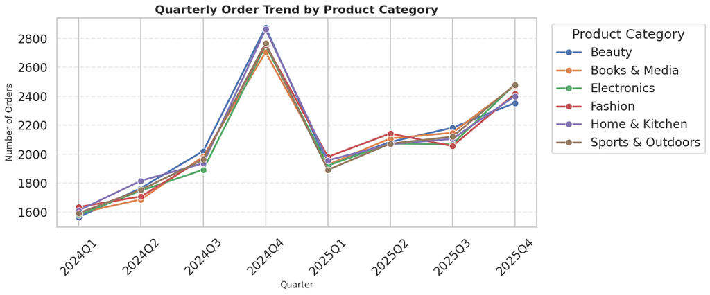

```python
# plt.figure(figsize=(12,6))

# sns.lineplot(
#     data=product_cat_wise_data,
#     x='order_qid',
#     y='no_of_orders',
#     hue='category'
# )

plt.figure(figsize=(14, 6))

sns.lineplot(
    data=product_cat_wise_data,
    x="order_qid",
    y="no_of_orders",
    hue="category",
    marker="o",
    linewidth=2.5
)

# Title and labels
plt.title(
    "Quarterly Order Trend by Product Category",
    fontsize=16,
    fontweight="bold"
)
plt.xlabel("Quarter", fontsize=12)
plt.ylabel("Number of Orders", fontsize=12)

# Improve readability
plt.xticks(rotation=45)
plt.grid(axis="y", linestyle="--", alpha=0.4)

# Legend
plt.legend(
    title="Product Category",
    bbox_to_anchor=(1.02, 1),
    loc="upper left",
    frameon=True
)

plt.tight_layout()
plt.show()
```

#### Region Wise Strategy

```python
df.columns
```

```
Index(['order_id', 'order_date', 'customer_id', 'customer_signup_date',
       'customer_region', 'customer_gender', 'customer_age',
       'marketing_source', 'loyalty_tier', 'product_id', 'category',
       'subcategory', 'unit_price', 'quantity', 'discount_pct', 'total_amount',
       'channel', 'payment_method', 'delivery_days', 'return_flag',
       'customer_rating', 'signup_year', 'signup_quarter', 'signup_qid',
       'order_year', 'order_quarter', 'order_qid'],
      dtype='object')
```

```python
region_wise_data = df.groupby(['order_qid', 'customer_region'])['order_id'].count().reset_index(name='no_of_orders').sort_values(by=['customer_region','order_qid'])

region_wise_data
```

|  | order_qid | customer_region | no_of_orders |
| --- | --- | --- | --- |
| 0 | 2024Q1 | Central | 1701 |
| 5 | 2024Q2 | Central | 1769 |
| 10 | 2024Q3 | Central | 2112 |
| 15 | 2024Q4 | Central | 3155 |
| 20 | 2025Q1 | Central | 2051 |
| 25 | 2025Q2 | Central | 2249 |
| 30 | 2025Q3 | Central | 2274 |
| 35 | 2025Q4 | Central | 2583 |
| 1 | 2024Q1 | East | 1724 |
| 6 | 2024Q2 | East | 1993 |
| 11 | 2024Q3 | East | 2279 |
| 16 | 2024Q4 | East | 3217 |
| 21 | 2025Q1 | East | 2210 |
| 26 | 2025Q2 | East | 2397 |
| 31 | 2025Q3 | East | 2382 |
| 36 | 2025Q4 | East | 2803 |
| 2 | 2024Q1 | North | 2183 |
| 7 | 2024Q2 | North | 2440 |
| 12 | 2024Q3 | North | 2557 |
| 17 | 2024Q4 | North | 3674 |
| 22 | 2025Q1 | North | 2503 |
| 27 | 2025Q2 | North | 2718 |
| 32 | 2025Q3 | North | 2786 |
| 37 | 2025Q4 | North | 3239 |
| 3 | 2024Q1 | South | 1943 |
| 8 | 2024Q2 | South | 1962 |
| 13 | 2024Q3 | South | 2254 |
| 18 | 2024Q4 | South | 3216 |
| 23 | 2025Q1 | South | 2377 |
| 28 | 2025Q2 | South | 2552 |
| 33 | 2025Q3 | South | 2510 |
| 38 | 2025Q4 | South | 2896 |
| 4 | 2024Q1 | West | 2027 |
| 9 | 2024Q2 | West | 2316 |
| 14 | 2024Q3 | West | 2567 |
| 19 | 2024Q4 | West | 3460 |
| 24 | 2025Q1 | West | 2467 |
| 29 | 2025Q2 | West | 2636 |
| 34 | 2025Q3 | West | 2731 |
| 39 | 2025Q4 | West | 3087 |

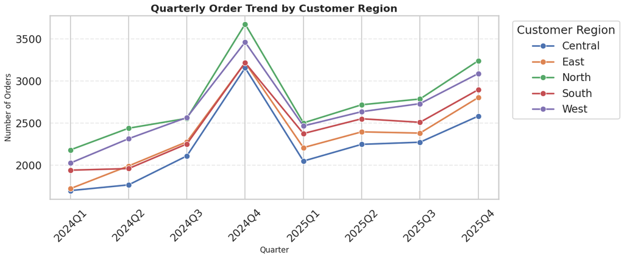

```python
# plt.figure(figsize=(12,6))

# sns.lineplot(
#     data=region_wise_data,
#     x='order_qid',
#     y='no_of_orders',
#     hue='customer_region'
# )

plt.figure(figsize=(14, 6))

sns.lineplot(
    data=region_wise_data,
    x="order_qid",
    y="no_of_orders",
    hue="customer_region",
    marker="o",
    linewidth=2.5
)

# Title and labels
plt.title(
    "Quarterly Order Trend by Customer Region",
    fontsize=16,
    fontweight="bold"
)
plt.xlabel("Quarter", fontsize=12)
plt.ylabel("Number of Orders", fontsize=12)

# Improve readability
plt.xticks(rotation=45)
plt.grid(axis="y", linestyle="--", alpha=0.4)

# Legend
plt.legend(
    title="Customer Region",
    bbox_to_anchor=(1.02, 1),
    loc="upper left",
    frameon=True
)

plt.tight_layout()
plt.show()
```

#### Sales Channel:

```python
channel_wise_data = df.groupby(['order_qid','channel'])['order_id'].count().reset_index(name='no_of_orders').sort_values(by=['channel', 'order_qid'])

channel_wise_data
```

|  | order_qid | channel | no_of_orders |
| --- | --- | --- | --- |
| 0 | 2024Q1 | Marketplace | 1388 |
| 3 | 2024Q2 | Marketplace | 1568 |
| 6 | 2024Q3 | Marketplace | 1752 |
| 9 | 2024Q4 | Marketplace | 2527 |
| 12 | 2025Q1 | Marketplace | 1792 |
| 15 | 2025Q2 | Marketplace | 1913 |
| 18 | 2025Q3 | Marketplace | 1889 |
| 21 | 2025Q4 | Marketplace | 2189 |
| 1 | 2024Q1 | Mobile App | 3866 |
| 4 | 2024Q2 | Mobile App | 4176 |
| 7 | 2024Q3 | Mobile App | 4678 |
| 10 | 2024Q4 | Mobile App | 6633 |
| 13 | 2025Q1 | Mobile App | 4657 |
| 16 | 2025Q2 | Mobile App | 4939 |
| 19 | 2025Q3 | Mobile App | 5191 |
| 22 | 2025Q4 | Mobile App | 5920 |
| 2 | 2024Q1 | Website | 4324 |
| 5 | 2024Q2 | Website | 4736 |
| 8 | 2024Q3 | Website | 5339 |
| 11 | 2024Q4 | Website | 7562 |
| 14 | 2025Q1 | Website | 5159 |
| 17 | 2025Q2 | Website | 5700 |
| 20 | 2025Q3 | Website | 5603 |
| 23 | 2025Q4 | Website | 6499 |

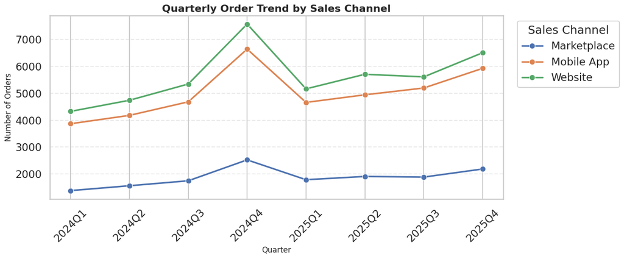

```python
# plt.figure(figsize=(12,6))

# sns.lineplot(
#     data=channel_wise_data,
#     x='order_qid',
#     y='no_of_orders',
#     hue='channel'
# )

plt.figure(figsize=(14, 6))

sns.lineplot(
    data=channel_wise_data,
    x="order_qid",
    y="no_of_orders",
    hue="channel",
    marker="o",
    linewidth=2.5
)

# Title and labels
plt.title(
    "Quarterly Order Trend by Sales Channel",
    fontsize=16,
    fontweight="bold"
)
plt.xlabel("Quarter", fontsize=12)
plt.ylabel("Number of Orders", fontsize=12)

# Improve readability
plt.xticks(rotation=45)
plt.grid(axis="y", linestyle="--", alpha=0.4)

# Legend
plt.legend(
    title="Sales Channel",
    bbox_to_anchor=(1.02, 1),
    loc="upper left",
    frameon=True
)

plt.tight_layout()
plt.show()
```

### Hypothesis Testing: We will be testing our hypothesis.

The discount percentage in q3 2025 was 16% more than q3 2024.**

H0 : The mean discount percentage of Q3 2024 was less than or equal to mean discount percentage of Q3 2025

Ha : The mean discount percentage of Q3 2025 was more than the mean discount percentage of Q3 2024.

```python
# Now this is going to be right tail test

# We are compairing two different independent samples here so we will use the t-test of independence for this.

from scipy.stats import ttest_ind

discount_pct_2024Q3 = df[df['order_qid'] == "2024Q3"]['discount_pct']
discount_pct_2025Q3 = df[df['order_qid'] == "2025Q3"]['discount_pct']

t_stat, p_value = ttest_ind(discount_pct_2024Q3, discount_pct_2025Q3)

alpha = 0.05

if p_value < alpha :
  print(f"The p-value is less than alpha: {p_value}. We reject the Null Hypothesis.")
else:
  print(f"The p-value is more than alpha: {p_value}. We fail to reject the Null hypothesis.")
```

```
The p-value is less than alpha: 0.0. We reject the Null Hypothesis.
```

- There is enough evidence to conclude that the discount percentage in Q3 2025 was significantly higher than the discount percentage in Q3 2025.

## **Recommendations:**

1. The marketing sources which are responsible for bringing in new customers is to be inspected and review for their performance and the point where the things are getting bad must be determind.
2. The discount approach must be converted from universal approach on each order to segment wise approch like:
- Giving more benefits to high value customers.
- Giving considerable discount to customers who are at risk to leave.
- Giving Discounts only on product categories which are moving considerably slow compared to others.

## Future Procedures:

Post application of the recommendation we can test the strength of recommendation and their impacts by:

1. Constantly monitoring the KPIs for the business.
2. Perform A/B Testing on the customers and find out whether the strategies were good enough.
3. Understand what factors have more potential to increase the business.
4. We can perform customers segmentation analysis to analyze, were there any changes in the performances.
5. Perform Root Cause analysis again and understand if the problem that we were facing actually fade off.

```
Business Problem
        │
        ▼
Revenue Declined
        │
        ▼
Revenue = Orders × AOV
        │
 ┌──────┴─────────┐
 ▼                ▼
Orders ↑      AOV ↓
 │              │
 │              ▼
 │        Discounts ↑
 │
 ▼
Customer Acquisition ↓
 │
 ▼
Marketing Investigation Needed
 │
 └──────────────┐
                ▼
Recommendations
 │
 ▼
KPIs & Future Monitoring
```